# Научная презентация по лабораторной работе №11

Дисциплина:Операционные системы

Абрамова У. М.

Российский университет дружбы народов, Москва, Россия

Математический институт имени Никольского, Москва, Россия

25.04.2025

# Информация

## Докладчик

- Абрамова Ульяна Михайловна
- Студент НММбд-01-24
- Российский университет дружбы народов
- 1132246782@pfur.ru
- https://github.com/Ulyana-abr

# Вводная часть

## Актуальность

- Работа с Emacs остаётся актуальной, несмотря на появление новых инструментов и редакторов каждый год, благодаря своей настраиваемости, интеграции с другими инструментами и работы на разных платформах

## Цели и задачи

- Познакомиться с операционной системой Linux.
- Получить практические навыки работы с редактором Emacs

## Материалы и методы

- linux
- emacs

## Содержание исследования

Открываю emacs (рис. 1).

[figure not shown]

emacs

## Содержание исследования

Создаю файл lab07.sh с помощью комбинации Ctrl-x Ctrl-f и набираю необходимый текст (рис. 2)

[figure not shown]

изменение файла

## Содержание исследования

Сохраняю файл с помощью комбинации Ctrl-x Ctrl-s.

## Содержание исследования

Далее проделываю с текстом стандартные процедуры редактирования, осуществленное комбинацией клавиш. Вырезаю командой “С-k” целую строку и вставляю ее в конец файла (C-y), после чего выделяю текст благодаря “C-space” (рис. 3)

## Содержание исследования

[figure not shown]

изменение текста

## Содержание исследования

Скопировав область в буфер обмена с помощью “M-w”, вставляю область в конец файла. (рис. 4)

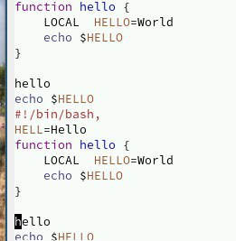

изменение текста

## Содержание исследования

Вновь выделяю эту область и на этот раз вырезаю её, используя “C-w”. Отменяю последнее действие благодаря “C-/”

## Содержание исследования

Далее учусь использовать команды по перемещению курсора: - перемещение курсора в начало строки - “C-a” - перемещение курсора в конец строки - “C-e” - перемещение курсора в начало буфера - “M-<” - перемещение курсора в конец буфера - “M->”

## Содержание исследования

Вывожу список активных буферов на экран (C-x C-b). (рис. 5)

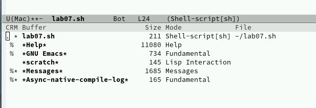

вывод активных буферов

## Содержание исследования

Перемещаюсь во вновь открытое окно (C-x o) со списком открытых буферов и переключитесь на другой буфер. (рис. 6)

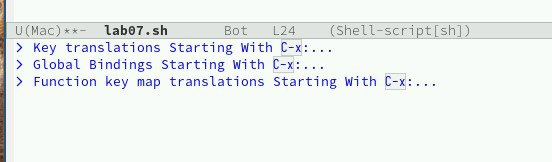

переключение на другой буфер

## Содержание исследования

Закрываю это окно (C-x 0). (рис. 7)

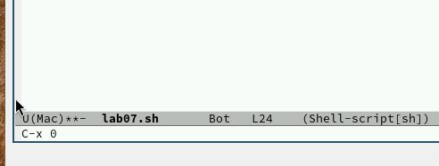

закрытие окна

## Содержание исследования

Теперь вновь переключаюсь между буферами, но уже без вывода их списка на экран (C-x b)

## Содержание исследования

Разделяю фрейм на два окна по вертикали (C-x 3) (рис. 8) , а затем каждое из этих окон на две части по горизонтали (C-x 2) (рис. 9)

## Содержание исследования

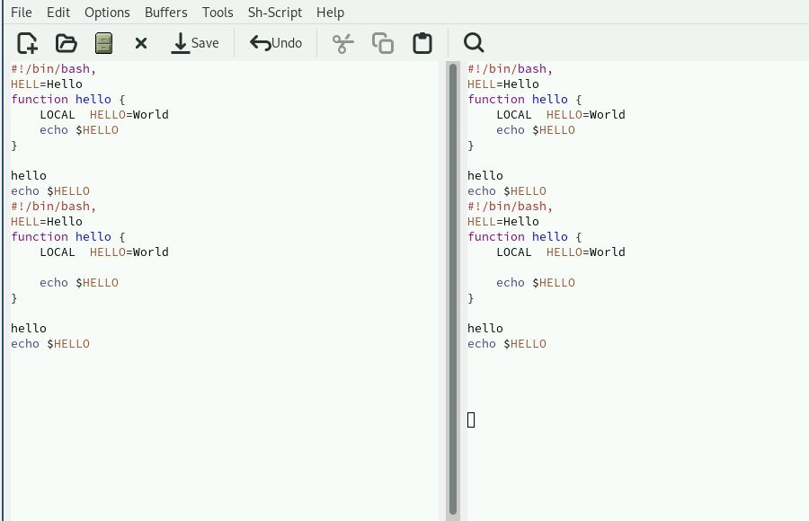

разделение фрейма

## Содержание исследования

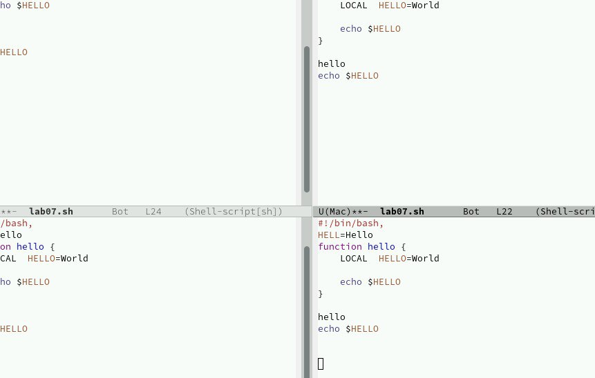

разделение фрейма

## Содержание исследования

В каждом из четырёх созданных окон открываю новый буфер (рис. 10)

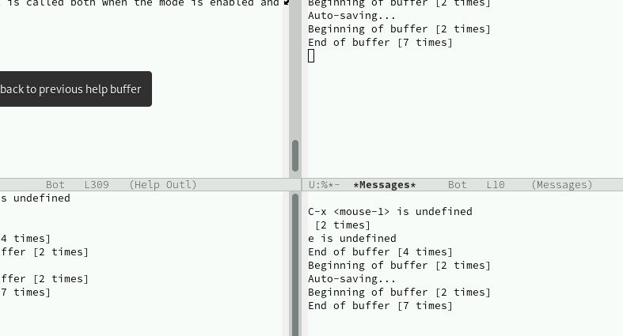

открытие буфера

## Содержание исследования

Переключаюсь в режим поиска (C-s) и нахожу несколько слов, присутствующих в тексте. (рис. 11)

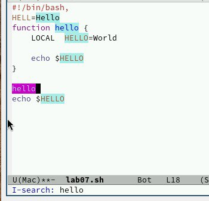

режим поиска

## Содержание исследования

Переключаюсь между результатами поиска, нажимая C-s. Выхожу из режима поиска, нажав C-g. Перехожу в режим поиска и замены (M-%), ввожу текст, который следует найти и заменить, нажимаю Enter , затем ввожу текст для замены. После того как подсветились результаты поиска, нажимаю ! для подтверждения замены. (рис. 12)

## Содержание исследования

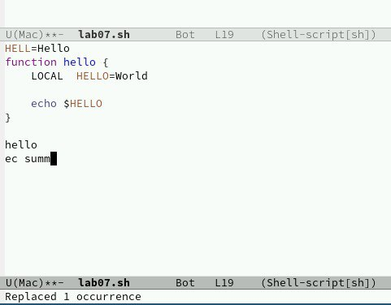

режим поиска и замены

## Содержание исследования

Испробую другой режим поиска, нажав M-s o, который отличается от обычного нахождением файла, а не фрагмента текста.

## Результаты

В данной работе мы познакомились с еще одним редактором операционной системой Linux. Получили практические навыки работы с редактором Emacs.

## Итоговый слайд

- Чем больше вы практикуетесь и пробуете новое, тем больше и чаще вы будете получать знаний и опыта в разных сферах.